# Datascience Capstone Presentation

August 30, 2017

## The application and assignment background

The purpose of this application is to predict the next word in a string of text.

This task was designed to tackle the challenge of working with an unfamiliar data type (text data). The data was provided by SwiftKey in a partnership with the Coursera John Hopkins Data Science program. SwiftKey is a leader in predictive text analytics and provided the raw dataset, a Corpus of unstructured text from news, twitter, and blog sources.

## Data preparation

- 30% of the Corpus data was extracted to use for model training. Using larger amounts of data created a tradeoff between the prediction time and accuracy.
- The data was cleaned by removing numbers, punctuation, characters, symbols, white spaces, and profanity words. All words were converted to lowercase.
- The data was then tokenized to break up words into word phrases of lengths 1-5 (known as n-grams).
- n-grams that occur only once in the dataset were removed.

A milestone report showing the code used for data extraction, data cleaning, data formatting, and generation of the file used to train the prediction algorithm can be found here https://rpubs.com/jhlevy/277211.

## How the model works

The algorithm uses a ngram model that predicts the next word based on frequencies of n-grams in the training dataset.

For phrases that are not in the training dataset, Katz's backoff model was used. The model starts by evaluating the input phrase (lets say 3 words), if that phrase does not exist in the database then the model will back off to the last two words in the phrase. If the last two words do not exist in the database, then the model will back off and consider the last word in the phrase. If there are still no matches, the model will predict the most frequent word in the database.

## Using the application

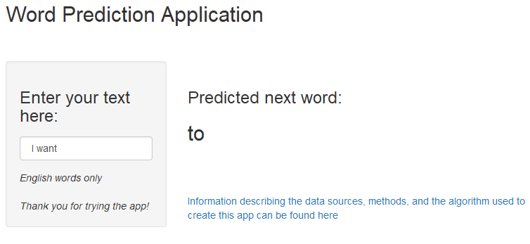